# ie48b-eblr

Irem Ozturk

24 01 2022

# Introduction

And this is the aggregated series (daily)

```r
daily_series=weather[,list(avg_production=mean(production)),by=list(date)]
head(daily_series)
```

```
##          date avg_production
## 1: 2019-09-01       94.06586
## 2: 2019-09-02       91.53619
## 3: 2019-09-03       91.10950
## 4: 2019-09-04       86.56820
## 5: 2019-09-05       89.03002
## 6: 2019-09-06       85.29621
```

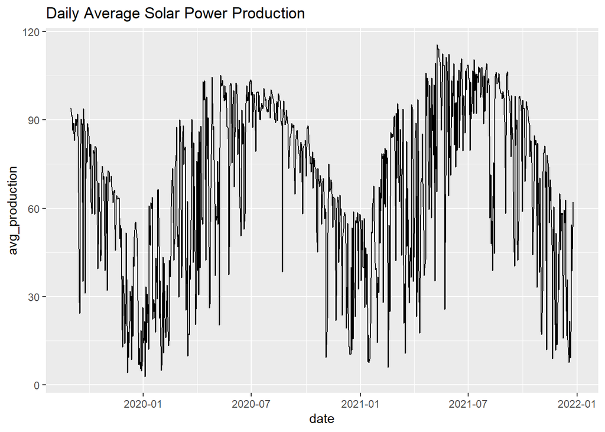

```r
daily_series[,date:=as.Date(date)]

ggplot(daily_series ,aes(x=date,y=avg_production)) + geom_line()+ ggtitle(label="Daily Average Solar Power Production ")
```

# Models

## Base Model - Linear Regression

base model is built with a trend and the hour information as a factor.

```r
lm_base<-lm(production~trend+as.factor(hour),weather)
summary(lm_base)
```

```
##
## Call:
## lm(formula = production ~ trend + as.factor(hour), data = weather)
##
## Residuals:
##      Min       1Q   Median       3Q      Max
## -207.570   -7.774    0.532   11.549  115.895
##
## Coefficients:
##                     Estimate Std. Error t value Pr(>|t|)
## (Intercept)       -9.024e+00  1.648e+00  -5.474 4.45e-08 ***
## trend              8.916e-04  5.419e-05  16.452  < 2e-16 ***
## as.factor(hour)1  -2.001e-03  2.198e+00  -0.001 0.999274
## as.factor(hour)2  -2.875e-03  2.198e+00  -0.001 0.998956
## as.factor(hour)3  -3.821e-04  2.198e+00   0.000 0.999861
## as.factor(hour)4   1.433e-02  2.198e+00   0.007 0.994800
## as.factor(hour)5   5.874e-01  2.198e+00   0.267 0.789307
## as.factor(hour)6   7.493e+00  2.198e+00   3.409 0.000654 ***
## as.factor(hour)7   3.803e+01  2.198e+00  17.301  < 2e-16 ***
## as.factor(hour)8   9.395e+01  2.198e+00  42.743  < 2e-16 ***
## as.factor(hour)9   1.521e+02  2.198e+00  69.186  < 2e-16 ***
## as.factor(hour)10  1.954e+02  2.198e+00  88.892  < 2e-16 ***
## as.factor(hour)11  2.182e+02  2.198e+00  99.277  < 2e-16 ***
## as.factor(hour)12  2.238e+02  2.198e+00 101.794  < 2e-16 ***
## as.factor(hour)13  2.133e+02  2.198e+00  97.045  < 2e-16 ***
## as.factor(hour)14  1.885e+02  2.198e+00  85.757  < 2e-16 ***
## as.factor(hour)15  1.460e+02  2.198e+00  66.432  < 2e-16 ***
## as.factor(hour)16  9.173e+01  2.198e+00  41.733  < 2e-16 ***
## as.factor(hour)17  4.020e+01  2.198e+00  18.288  < 2e-16 ***
## as.factor(hour)18  9.934e+00  2.198e+00   4.520 6.23e-06 ***
## as.factor(hour)19  1.005e+00  2.198e+00   0.457 0.647610
## as.factor(hour)20 -3.304e-03  2.198e+00  -0.002 0.998801
## as.factor(hour)21 -1.198e-02  2.198e+00  -0.005 0.995650
## as.factor(hour)22 -2.400e-02  2.198e+00  -0.011 0.991289
## as.factor(hour)23 -2.414e-02  2.198e+00  -0.011 0.991239
## ---
## Signif. codes:  0 '***' 0.001 '**' 0.01 '*' 0.05 '.' 0.1 ' ' 1
##
## Residual standard error: 45.18 on 20255 degrees of freedom
## Multiple R-squared:  0.7796, Adjusted R-squared:  0.7793
## F-statistic:  2985 on 24 and 20255 DF,  p-value: < 2.2e-16
```

As can be seen above, night hours are not significant for the model which is obvious. Also, adjusted R-squared= 0.7793. Here are some plots regarding some days to compare actual and predicted values.

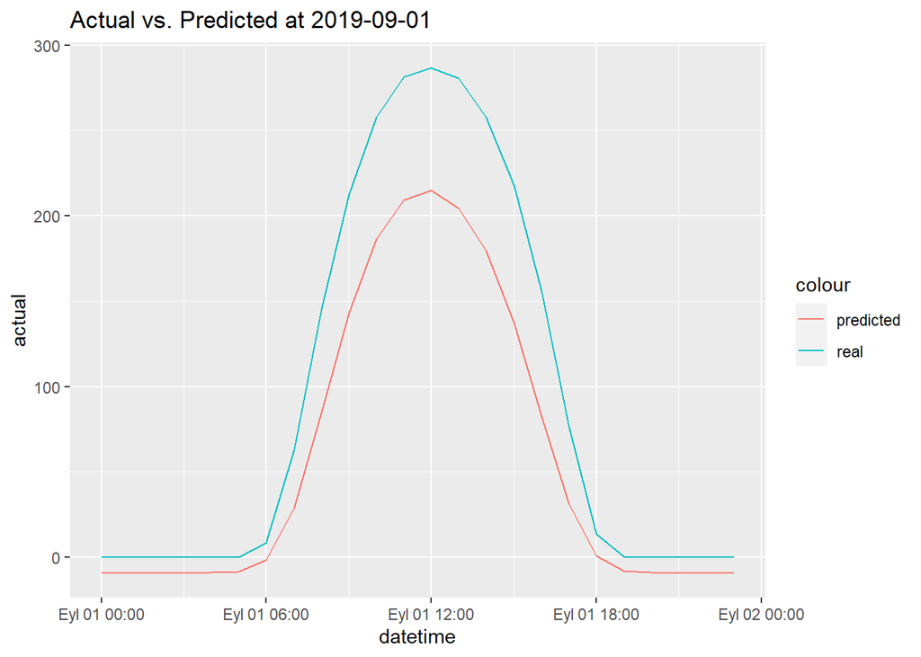

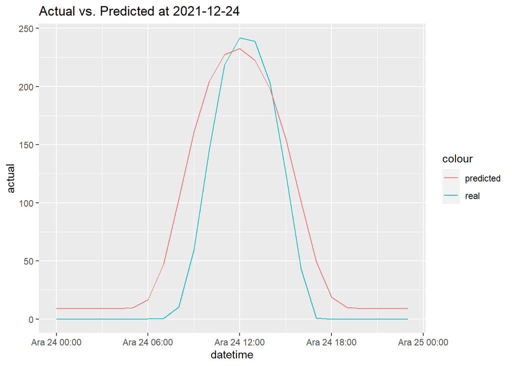

## Linear Regression with Temperature and Shortwave Radiation

```r
lm_base_deneme=lm(production~trend+as.factor(hour)+DSWRF_38_35+DSWRF_38_35.25+DSWRF_38_35.5+DSWRF_38_35.75+
                            DSWRF_38_36+DSWRF_38.25_35+DSWRF_38.25_35.25+DSWRF_38.25_35.5+
                            DSWRF_38.25_35.75+DSWRF_38.25_36+DSWRF_38.5_35+DSWRF_38.5_35.25+
                            DSWRF_38.5_35.5+DSWRF_38.5_35.75+DSWRF_38.5_36+DSWRF_38.75_35+
                            DSWRF_38.75_35.25+DSWRF_38.75_35.5+DSWRF_38.75_35.75+DSWRF_38.75_36+
                            DSWRF_39_35+DSWRF_39_35.25+DSWRF_39_35.5+DSWRF_39_35.75+DSWRF_39_36+
                            TMP_38_35+TMP_38_35.25+TMP_38_35.5+TMP_38_35.75+
                            TMP_38_36+TMP_38.25_35+TMP_38.25_35.25+TMP_38.25_35.5+
                            TMP_38.25_35.75+TMP_38.25_36+TMP_38.5_35+TMP_38.5_35.25+
                            TMP_38.5_35.5+TMP_38.5_35.75+TMP_38.5_36+TMP_38.75_35+
                            TMP_38.75_35.25+TMP_38.75_35.5+TMP_38.75_35.75+TMP_38.75_36+
                            TMP_39_35+TMP_39_35.25+TMP_39_35.5+TMP_39_35.75+TMP_39_36,weather)
summary(lm_base_deneme)
```

```
##
## Call:
## lm(formula = production ~ trend + as.factor(hour) + DSWRF_38_35 +
##     DSWRF_38_35.25 + DSWRF_38_35.5 + DSWRF_38_35.75 + DSWRF_38_36 +
##     DSWRF_38.25_35 + DSWRF_38.25_35.25 + DSWRF_38.25_35.5 + DSWRF_38.25_35.75 +
##     DSWRF_38.25_36 + DSWRF_38.5_35 + DSWRF_38.5_35.25 + DSWRF_38.5_35.5 +
##     DSWRF_38.5_35.75 + DSWRF_38.5_36 + DSWRF_38.75_35 + DSWRF_38.75_35.25 +
##     DSWRF_38.75_35.5 + DSWRF_38.75_35.75 + DSWRF_38.75_36 + DSWRF_39_35 +
##     DSWRF_39_35.25 + DSWRF_39_35.5 + DSWRF_39_35.75 + DSWRF_39_36 +
##     TMP_38_35 + TMP_38_35.25 + TMP_38_35.5 + TMP_38_35.75 + TMP_38_36 +
##     TMP_38.25_35 + TMP_38.25_35.25 + TMP_38.25_35.5 + TMP_38.25_35.75 +
##     TMP_38.25_36 + TMP_38.5_35 + TMP_38.5_35.25 + TMP_38.5_35.5 +
##     TMP_38.5_35.75 + TMP_38.5_36 + TMP_38.75_35 + TMP_38.75_35.25 +
##     TMP_38.75_35.5 + TMP_38.75_35.75 + TMP_38.75_36 + TMP_39_35 +
##     TMP_39_35.25 + TMP_39_35.5 + TMP_39_35.75 + TMP_39_36, data = weather)
##
## Residuals:
##      Min       1Q   Median       3Q      Max
## -204.722  -11.616    1.295   16.046  125.440
##
## Coefficients:
##                     Estimate Std. Error t value Pr(>|t|)
## (Intercept)       -2.689e+02  1.087e+01 -24.746  < 2e-16 ***
## trend              4.402e-04  3.845e-05  11.448  < 2e-16 ***
## as.factor(hour)1  -6.677e-01  1.517e+00  -0.440 0.659812
## as.factor(hour)2  -1.165e+00  1.519e+00  -0.767 0.442837
## as.factor(hour)3  -1.530e+00  1.521e+00  -1.006 0.314339
## as.factor(hour)4  -2.002e+00  1.524e+00  -1.314 0.188924
## as.factor(hour)5  -1.717e+00  1.525e+00  -1.125 0.260412
## as.factor(hour)6   4.318e+00  1.527e+00   2.829 0.004677 **
## as.factor(hour)7   3.045e+01  1.534e+00  19.846  < 2e-16 ***
## as.factor(hour)8   7.769e+01  1.551e+00  50.084  < 2e-16 ***
## as.factor(hour)9   1.246e+02  1.577e+00  79.013  < 2e-16 ***
## as.factor(hour)10  9.365e+01  1.804e+00  51.925  < 2e-16 ***
## as.factor(hour)11  1.027e+02  1.872e+00  54.895  < 2e-16 ***
## as.factor(hour)12  9.847e+01  1.921e+00  51.272  < 2e-16 ***
## as.factor(hour)13  8.284e+01  1.949e+00  42.514  < 2e-16 ***
## as.factor(hour)14  5.670e+01  1.956e+00  28.982  < 2e-16 ***
## as.factor(hour)15  1.688e+01  1.943e+00   8.687  < 2e-16 ***
## as.factor(hour)16 -6.074e+00  1.778e+00  -3.417 0.000635 ***
```

[output cut: 49 more lines]

```
## TMP_38.75_35.5     1.406e+00  4.544e-01   3.094 0.001977 **
## TMP_38.75_35.75    2.468e-01  4.373e-01   0.564 0.572521
## TMP_38.75_36      -5.348e-01  4.117e-01  -1.299 0.194001
## TMP_39_35         -4.500e+00  4.887e-01  -9.208  < 2e-16 ***
## TMP_39_35.25       3.747e+00  6.647e-01   5.637 1.75e-08 ***
## TMP_39_35.5        2.746e+00  6.402e-01   4.290 1.80e-05 ***
## TMP_39_35.75      -2.103e+00  6.010e-01  -3.499 0.000468 ***
## TMP_39_36         -2.199e+00  4.933e-01  -4.457 8.36e-06 ***
## ---
## Signif. codes:  0 '***' 0.001 '**' 0.01 '*' 0.05 '.' 0.1 ' ' 1
##
## Residual standard error: 31.15 on 20199 degrees of freedom
##   (6 observations deleted due to missingness)
## Multiple R-squared:  0.8955, Adjusted R-squared:  0.8951
## F-statistic:  2339 on 74 and 20199 DF,  p-value: < 2.2e-16
```

Adjusted R squared has improved.The information about some locations are insignificant for the model.

## Explainable Boosted Linear Regression Model 1

Now we are going to try to elaborete this model and improve the adjusted R-squared value To do that explainable boosted linear regression with depth 4 will be used. As a factor temperature data for the 25 different coordinates has used. Here is the regression tree:

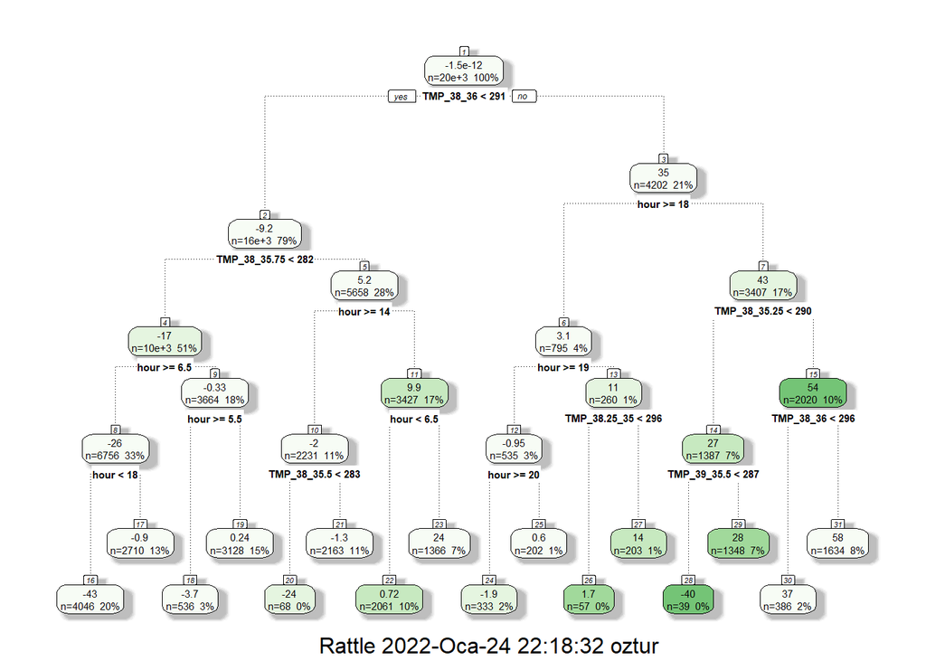

```r
fit_res_tree=rpart(residual~TMP_38_35+TMP_38_35.25+TMP_38_35.5+TMP_38_35.75+
                            TMP_38_36+TMP_38.25_35+TMP_38.25_35.25+TMP_38.25_35.5+
                            TMP_38.25_35.75+TMP_38.25_36+TMP_38.5_35+TMP_38.5_35.25+
                            TMP_38.5_35.5+TMP_38.5_35.75+TMP_38.5_36+TMP_38.75_35+
                            TMP_38.75_35.25+TMP_38.75_35.5+TMP_38.75_35.75+TMP_38.75_36+
                            TMP_39_35+TMP_39_35.25+TMP_39_35.5+TMP_39_35.75+TMP_39_36+
                            hour,tmp,control=rpart.control(cp=0,maxdepth=4))

fancyRpartPlot(fit_res_tree)
```

the biggest error has shown in box 31 as 58. So, we need to track the path and add some new variables. after that second model can bu created. Results:

```r
tmp[,tm_gt:=as.numeric(TMP_38_36>296)]

tmp[,tm_gt2:=as.numeric(TMP_38_35.25>=290)]
tmp[,hour_ls:=as.numeric(hour<18)]

lm_basev2=lm(production~trend+as.factor(hour)+tm_gt:tm_gt2:hour_ls,tmp)
summary(lm_basev2)
```

```
##
## Call:
## lm(formula = production ~ trend + as.factor(hour) + tm_gt:tm_gt2:hour_ls,
##     data = tmp)
##
## Residuals:
##      Min       1Q   Median       3Q      Max
## -192.291   -7.299    0.053    7.840  135.304
##
## Coefficients:
##                        Estimate Std. Error t value Pr(>|t|)
## (Intercept)          -8.179e+00  1.510e+00  -5.418 6.11e-08 ***
## trend                 8.092e-04  4.964e-05  16.301  < 2e-16 ***
## as.factor(hour)1     -1.138e-02  2.013e+00  -0.006 0.995488
## as.factor(hour)2     -1.218e-02  2.013e+00  -0.006 0.995174
## as.factor(hour)3     -9.601e-03  2.013e+00  -0.005 0.996195
## as.factor(hour)4      5.189e-03  2.013e+00   0.003 0.997943
## as.factor(hour)5      5.783e-01  2.013e+00   0.287 0.773896
## as.factor(hour)6      7.484e+00  2.013e+00   3.718 0.000201 ***
## as.factor(hour)7      3.790e+01  2.014e+00  18.822  < 2e-16 ***
## as.factor(hour)8      9.090e+01  2.014e+00  45.146  < 2e-16 ***
## as.factor(hour)9      1.461e+02  2.015e+00  72.484  < 2e-16 ***
## as.factor(hour)10     1.857e+02  2.019e+00  91.955  < 2e-16 ***
## as.factor(hour)11     2.044e+02  2.025e+00 100.935  < 2e-16 ***
## as.factor(hour)12     2.074e+02  2.030e+00 102.182  < 2e-16 ***
## as.factor(hour)13     1.953e+02  2.033e+00  96.058  < 2e-16 ***
## as.factor(hour)14     1.695e+02  2.036e+00  83.244  < 2e-16 ***
## as.factor(hour)15     1.271e+02  2.036e+00  62.427  < 2e-16 ***
## as.factor(hour)16     7.453e+01  2.032e+00  36.682  < 2e-16 ***
## as.factor(hour)17     2.473e+01  2.028e+00  12.193  < 2e-16 ***
## as.factor(hour)18     9.927e+00  2.013e+00   4.931 8.24e-07 ***
## as.factor(hour)19     9.939e-01  2.014e+00   0.494 0.621610
## as.factor(hour)20    -1.112e-02  2.013e+00  -0.006 0.995592
## as.factor(hour)21    -1.972e-02  2.013e+00  -0.010 0.992185
## as.factor(hour)22    -3.165e-02  2.013e+00  -0.016 0.987455
## as.factor(hour)23    -3.171e-02  2.013e+00  -0.016 0.987433
## tm_gt:tm_gt2:hour_ls  7.340e+01  1.173e+00  62.555  < 2e-16 ***
## ---
## Signif. codes:  0 '***' 0.001 '**' 0.01 '*' 0.05 '.' 0.1 ' ' 1
##
## Residual standard error: 41.36 on 20251 degrees of freedom
##   (3 observations deleted due to missingness)
## Multiple R-squared:  0.8153, Adjusted R-squared:  0.8151
## F-statistic:  3576 on 25 and 20251 DF,  p-value: < 2.2e-16
```

```r
tmp[,predicted2:=predict(lm_basev2,tmp)]
```

As we can see R squared values has improved significantly compared to base model. Here are the plots demonstrating the same days above:

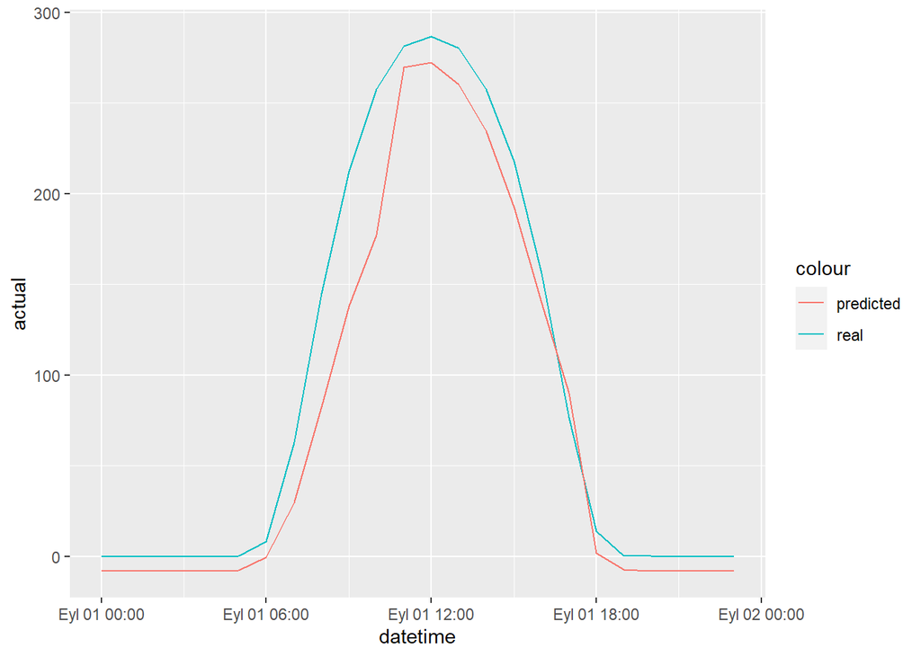

```r
ggplot(tmp[date=='2019-09-01'] ,aes(x=datetime)) +
  geom_line(aes(y=actual,color='real')) +
  geom_line(aes(y=predicted2,color='predicted'))
```

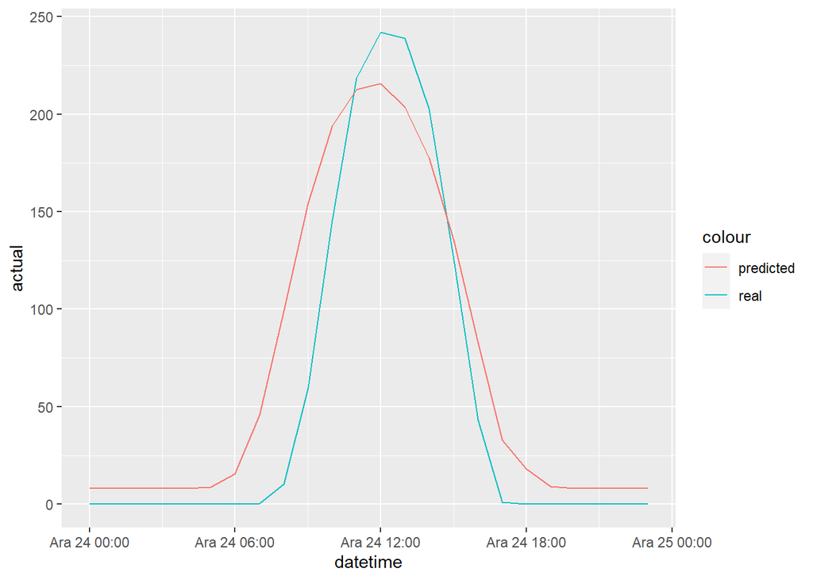

```r
ggplot(tmp[date=='2021-12-24'] ,aes(x=datetime)) +
  geom_line(aes(y=actual,color='real')) +
  geom_line(aes(y=predicted2,color='predicted'))
```

## Explainable Boosted Linear Regression Model 2

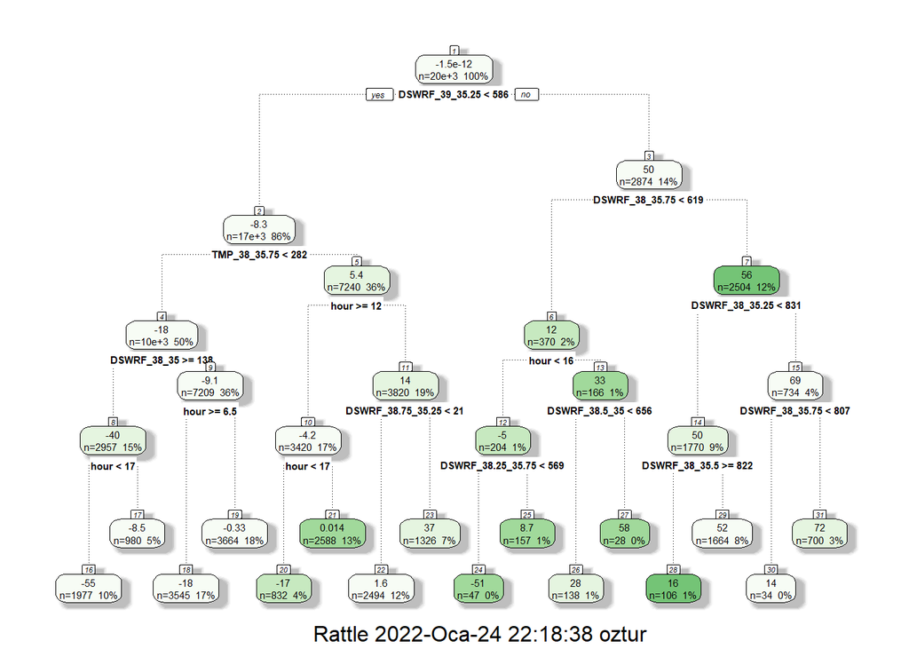

```r
fit_res_tree2=rpart(residual~DSWRF_38_35+DSWRF_38_35.25+DSWRF_38_35.5+DSWRF_38_35.75+
                            DSWRF_38_36+DSWRF_38.25_35+DSWRF_38.25_35.25+DSWRF_38.25_35.5+
                            DSWRF_38.25_35.75+DSWRF_38.25_36+DSWRF_38.5_35+DSWRF_38.5_35.25+
                            DSWRF_38.5_35.5+DSWRF_38.5_35.75+DSWRF_38.5_36+DSWRF_38.75_35+
                            DSWRF_38.75_35.25+DSWRF_38.75_35.5+DSWRF_38.75_35.75+DSWRF_38.75_36+
                            DSWRF_39_35+DSWRF_39_35.25+DSWRF_39_35.5+DSWRF_39_35.75+DSWRF_39_36+
                            TMP_38_35+TMP_38_35.25+TMP_38_35.5+TMP_38_35.75+
                            TMP_38_36+TMP_38.25_35+TMP_38.25_35.25+TMP_38.25_35.5+
                            TMP_38.25_35.75+TMP_38.25_36+TMP_38.5_35+TMP_38.5_35.25+
                            TMP_38.5_35.5+TMP_38.5_35.75+TMP_38.5_36+TMP_38.75_35+
                            TMP_38.75_35.25+TMP_38.75_35.5+TMP_38.75_35.75+TMP_38.75_36+
                            TMP_39_35+TMP_39_35.25+TMP_39_35.5+TMP_39_35.75+TMP_39_36+
                            hour,tmp,control=rpart.control(cp=0,maxdepth=4))

fancyRpartPlot(fit_res_tree2)
```

Box 16 indicates error -55 for the 10% of the data. So, new feature will be added to the base model to cover this error.

```r
tmp[,tm_gt3:=as.numeric(DSWRF_39_35.25<586)]

tmp[,tm_gt4:=as.numeric(TMP_38_35.75<282)]
tmp[,tm_gt5:=as.numeric(DSWRF_38_35>=138)]

tmp[,hour_ls2:=as.numeric(hour<17)]

lm_basev3=lm(production~trend+as.factor(hour)+tm_gt3:tm_gt4:tm_gt5:hour_ls2,tmp)
summary(lm_basev3)
```

```
##
## Call:
## lm(formula = production ~ trend + as.factor(hour) + tm_gt3:tm_gt4:tm_gt5:hour_ls2,
##     data = tmp)
##
## Residuals:
##      Min       1Q   Median       3Q      Max
## -219.697   -6.356    0.447    9.872  196.497
##
## Coefficients:
##                                 Estimate Std. Error t value Pr(>|t|)
## (Intercept)                   -7.427e+00  1.459e+00  -5.090 3.60e-07 ***
## trend                          7.348e-04  4.800e-05  15.307  < 2e-16 ***
## as.factor(hour)1              -1.044e-02  1.945e+00  -0.005 0.995717
## as.factor(hour)2              -1.116e-02  1.945e+00  -0.006 0.995423
## as.factor(hour)3              -8.508e-03  1.945e+00  -0.004 0.996510
## as.factor(hour)4               6.357e-03  1.945e+00   0.003 0.997392
## as.factor(hour)5               5.795e-01  1.945e+00   0.298 0.765724
## as.factor(hour)6               7.485e+00  1.945e+00   3.849 0.000119 ***
## as.factor(hour)7               3.808e+01  1.946e+00  19.571  < 2e-16 ***
## as.factor(hour)8               9.395e+01  1.945e+00  48.303  < 2e-16 ***
## as.factor(hour)9               1.528e+02  1.945e+00  78.541  < 2e-16 ***
## as.factor(hour)10              2.266e+02  1.989e+00 113.936  < 2e-16 ***
## as.factor(hour)11              2.482e+02  1.985e+00 124.989  < 2e-16 ***
## as.factor(hour)12              2.524e+02  1.982e+00 127.346  < 2e-16 ***
## as.factor(hour)13              2.388e+02  1.974e+00 120.956  < 2e-16 ***
## as.factor(hour)14              2.124e+02  1.971e+00 107.729  < 2e-16 ***
## as.factor(hour)15              1.703e+02  1.972e+00  86.393  < 2e-16 ***
## as.factor(hour)16              1.185e+02  1.978e+00  59.922  < 2e-16 ***
## as.factor(hour)17              4.019e+01  1.945e+00  20.665  < 2e-16 ***
## as.factor(hour)18              9.949e+00  1.946e+00   5.114 3.18e-07 ***
## as.factor(hour)19              9.957e-01  1.946e+00   0.512 0.608814
## as.factor(hour)20             -8.764e-03  1.945e+00  -0.005 0.996405
## as.factor(hour)21             -1.729e-02  1.945e+00  -0.009 0.992909
## as.factor(hour)22             -2.914e-02  1.945e+00  -0.015 0.988044
## as.factor(hour)23             -2.912e-02  1.945e+00  -0.015 0.988053
## tm_gt3:tm_gt4:tm_gt5:hour_ls2 -8.324e+01  1.109e+00 -75.063  < 2e-16 ***
## ---
## Signif. codes:  0 '***' 0.001 '**' 0.01 '*' 0.05 '.' 0.1 ' ' 1
##
## Residual standard error: 39.97 on 20248 degrees of freedom
##   (6 observations deleted due to missingness)
## Multiple R-squared:  0.8276, Adjusted R-squared:  0.8274
## F-statistic:  3887 on 25 and 20248 DF,  p-value: < 2.2e-16
```

```r
tmp[,predicted3:=predict(lm_basev3,tmp)]
```

Adjusted R^2 is better than EBLR model 1.

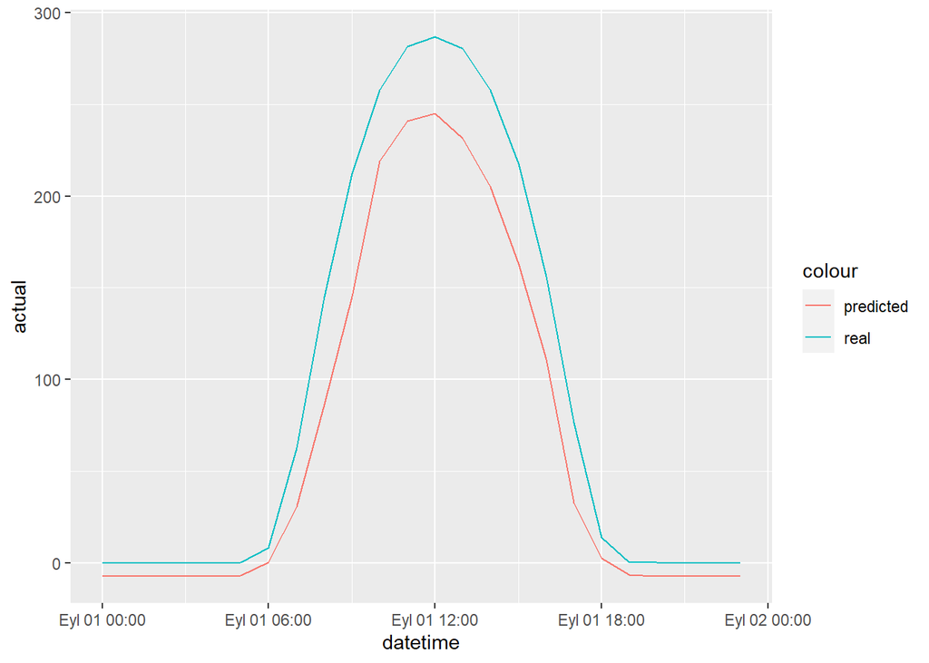

```r
ggplot(tmp[date=='2019-09-01'] ,aes(x=datetime)) +
  geom_line(aes(y=actual,color='real')) +
  geom_line(aes(y=predicted3,color='predicted'))
```

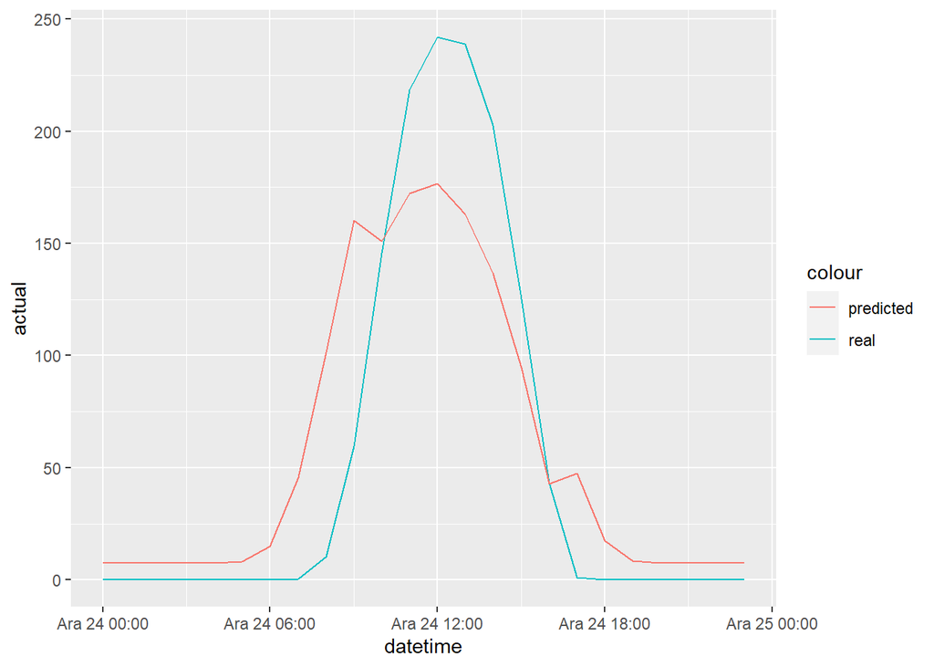

```r
ggplot(tmp[date=='2021-12-24'] ,aes(x=datetime)) +
  geom_line(aes(y=actual,color='real')) +
  geom_line(aes(y=predicted3,color='predicted'))
```

## combination of Models

```r
lm_combine=lm(production~trend+as.factor(hour)+DSWRF_38_35+DSWRF_38_35.25+DSWRF_38_35.5+DSWRF_38_35.75+
                            DSWRF_38_36+DSWRF_38.25_35+DSWRF_38.25_35.25+DSWRF_38.25_35.5+
                            DSWRF_38.25_35.75+DSWRF_38.25_36+DSWRF_38.5_35+DSWRF_38.5_35.25+
                            DSWRF_38.5_35.5+DSWRF_38.5_35.75+DSWRF_38.5_36+DSWRF_38.75_35+
                            DSWRF_38.75_35.25+DSWRF_38.75_35.5+DSWRF_38.75_35.75+DSWRF_38.75_36+
                            DSWRF_39_35+DSWRF_39_35.25+DSWRF_39_35.5+DSWRF_39_35.75+DSWRF_39_36+
                            TMP_38_35+TMP_38_35.25+TMP_38_35.5+TMP_38_35.75+
                            TMP_38_36+TMP_38.25_35+TMP_38.25_35.25+TMP_38.25_35.5+
                            TMP_38.25_35.75+TMP_38.25_36+TMP_38.5_35+TMP_38.5_35.25+
                            TMP_38.5_35.5+TMP_38.5_35.75+TMP_38.5_36+TMP_38.75_35+
                            TMP_38.75_35.25+TMP_38.75_35.5+TMP_38.75_35.75+TMP_38.75_36+
                            TMP_39_35+TMP_39_35.25+TMP_39_35.5+TMP_39_35.75+TMP_39_36+tm_gt3:tm_gt4:tm_gt5:hour_ls2,tmp)
summary(lm_combine)
```

```
##
## Call:
## lm(formula = production ~ trend + as.factor(hour) + DSWRF_38_35 +
##     DSWRF_38_35.25 + DSWRF_38_35.5 + DSWRF_38_35.75 + DSWRF_38_36 +
##     DSWRF_38.25_35 + DSWRF_38.25_35.25 + DSWRF_38.25_35.5 + DSWRF_38.25_35.75 +
##     DSWRF_38.25_36 + DSWRF_38.5_35 + DSWRF_38.5_35.25 + DSWRF_38.5_35.5 +
##     DSWRF_38.5_35.75 + DSWRF_38.5_36 + DSWRF_38.75_35 + DSWRF_38.75_35.25 +
##     DSWRF_38.75_35.5 + DSWRF_38.75_35.75 + DSWRF_38.75_36 + DSWRF_39_35 +
##     DSWRF_39_35.25 + DSWRF_39_35.5 + DSWRF_39_35.75 + DSWRF_39_36 +
##     TMP_38_35 + TMP_38_35.25 + TMP_38_35.5 + TMP_38_35.75 + TMP_38_36 +
##     TMP_38.25_35 + TMP_38.25_35.25 + TMP_38.25_35.5 + TMP_38.25_35.75 +
##     TMP_38.25_36 + TMP_38.5_35 + TMP_38.5_35.25 + TMP_38.5_35.5 +
##     TMP_38.5_35.75 + TMP_38.5_36 + TMP_38.75_35 + TMP_38.75_35.25 +
##     TMP_38.75_35.5 + TMP_38.75_35.75 + TMP_38.75_36 + TMP_39_35 +
##     TMP_39_35.25 + TMP_39_35.5 + TMP_39_35.75 + TMP_39_36 + tm_gt3:tm_gt4:tm_gt5:hour_ls2,
##     data = tmp)
##
## Residuals:
##      Min       1Q   Median       3Q      Max
## -208.891  -11.145    1.141   15.110  129.641
##
## Coefficients:
##                                 Estimate Std. Error t value Pr(>|t|)
## (Intercept)                   -2.466e+02  1.087e+01 -22.676  < 2e-16 ***
## trend                          4.495e-04  3.819e-05  11.771  < 2e-16 ***
## as.factor(hour)1              -6.874e-01  1.506e+00  -0.456 0.648172
## as.factor(hour)2              -1.189e+00  1.508e+00  -0.788 0.430450
## as.factor(hour)3              -1.569e+00  1.510e+00  -1.039 0.298792
## as.factor(hour)4              -2.007e+00  1.513e+00  -1.327 0.184651
## as.factor(hour)5              -1.740e+00  1.515e+00  -1.149 0.250573
## as.factor(hour)6               4.342e+00  1.516e+00   2.864 0.004190 **
## as.factor(hour)7               3.076e+01  1.524e+00  20.190  < 2e-16 ***
## as.factor(hour)8               7.862e+01  1.541e+00  51.002  < 2e-16 ***
## as.factor(hour)9               1.266e+02  1.571e+00  80.583  < 2e-16 ***
## as.factor(hour)10              1.082e+02  1.988e+00  54.421  < 2e-16 ***
## as.factor(hour)11              1.182e+02  2.072e+00  57.036  < 2e-16 ***
## as.factor(hour)12              1.145e+02  2.133e+00  53.713  < 2e-16 ***
## as.factor(hour)13              9.880e+01  2.154e+00  45.859  < 2e-16 ***
## as.factor(hour)14              7.252e+01  2.158e+00  33.608  < 2e-16 ***
## as.factor(hour)15              3.265e+01  2.144e+00  15.227  < 2e-16 ***
```

[output cut: 51 more lines]

```
## TMP_38.75_35.75               -4.449e-02  4.346e-01  -0.102 0.918455
## TMP_38.75_36                  -3.167e-01  4.091e-01  -0.774 0.438790
## TMP_39_35                     -4.049e+00  4.861e-01  -8.329  < 2e-16 ***
## TMP_39_35.25                   3.282e+00  6.607e-01   4.968 6.81e-07 ***
## TMP_39_35.5                    2.525e+00  6.359e-01   3.970 7.20e-05 ***
## TMP_39_35.75                  -1.996e+00  5.969e-01  -3.344 0.000828 ***
## TMP_39_36                     -2.529e+00  4.903e-01  -5.158 2.52e-07 ***
## tm_gt3:tm_gt4:tm_gt5:hour_ls2 -1.863e+01  1.106e+00 -16.850  < 2e-16 ***
## ---
## Signif. codes:  0 '***' 0.001 '**' 0.01 '*' 0.05 '.' 0.1 ' ' 1
##
## Residual standard error: 30.94 on 20198 degrees of freedom
##   (6 observations deleted due to missingness)
## Multiple R-squared:  0.8969, Adjusted R-squared:  0.8966
## F-statistic:  2344 on 75 and 20198 DF,  p-value: < 2.2e-16
```

```r
tmp[,predicted_combined:=predict(lm_combine,tmp)]
```

Adjusted R^2 is slightly better than linear regression with temperature and the downward radiation. Here is the plots for the same days.

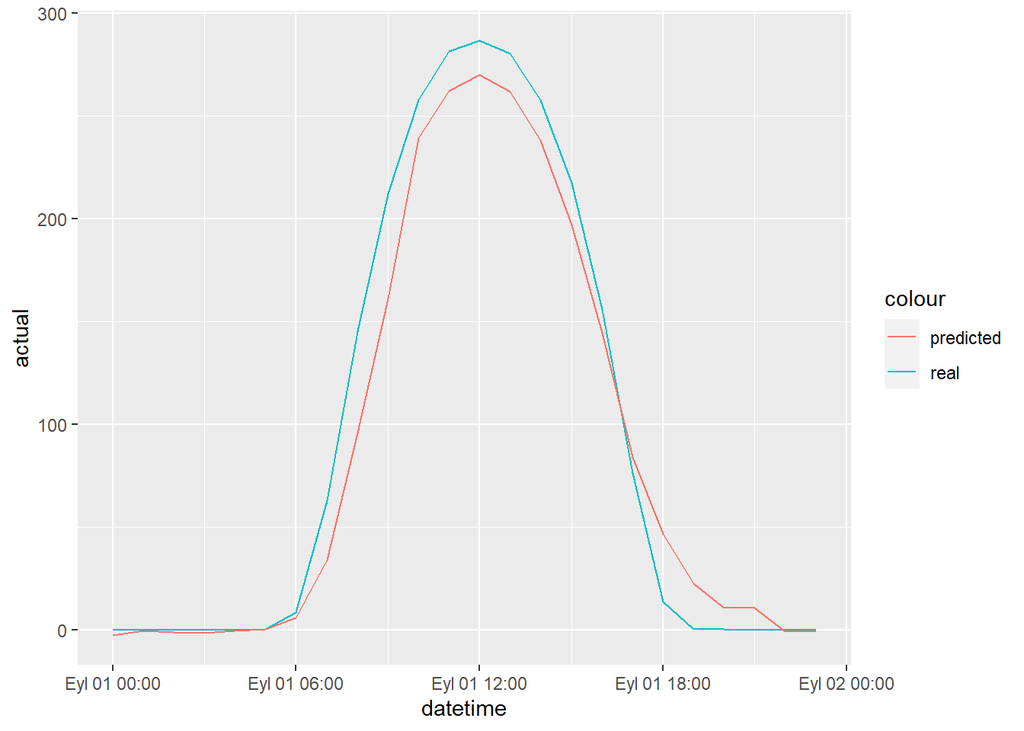

```r
ggplot(tmp[date=='2019-09-01'] ,aes(x=datetime)) +
  geom_line(aes(y=actual,color='real')) +
  geom_line(aes(y=predicted_combined,color='predicted'))
```

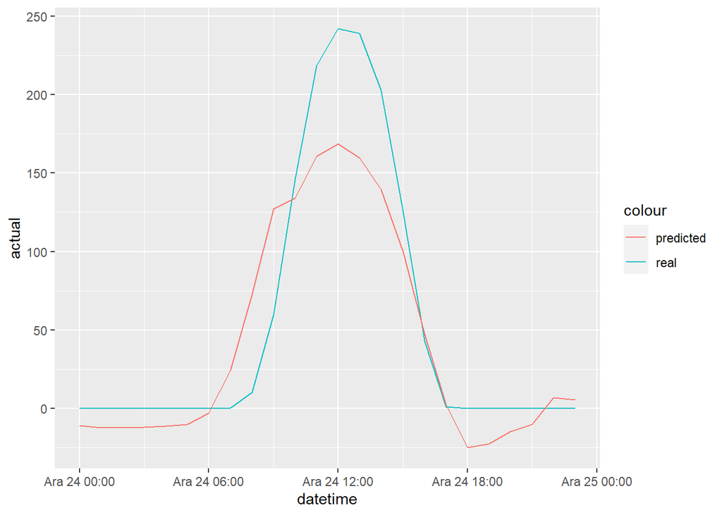

```r
ggplot(tmp[date=='2021-12-24'] ,aes(x=datetime)) +
  geom_line(aes(y=actual,color='real')) +
  geom_line(aes(y=predicted_combined,color='predicted'))
```

# Conclusion

Here is the final table that shows the predicted values with 4 models explained before and the the lagged values.

```r
weather[, lagged:= shift(weather$production, n=48, fill=NA)]

last_table <- data.table(date=weather$date, hour=weather$hour, production=weather$production, lagg_48=weather$lagged, base_predicted=tmp$predicted, reg_tree_predicted1=tmp$predicted2,reg_tree_predicted2=tmp$predicted3,combined_predicted=tmp$predicted_combined)
tail(last_table, 24)
```

```
##           date hour production lagg_48 base_predicted reg_tree_predicted1
##  1: 2021-12-25    0   0.000000       0       9.037296            8.212228
##  2: 2021-12-25    1   0.000000       0       9.036187            8.201653
##  3: 2021-12-25    2   0.000000       0       9.036204            8.201670
##  4: 2021-12-25    3   0.000000       0       9.039589            8.205055
##  5: 2021-12-25    4   0.000000       0       9.055188            8.220654
##  6: 2021-12-25    5   0.000000       0       9.629115            8.794581
##  7: 2021-12-25    6   0.056599       0      16.535668           15.701134
##  8: 2021-12-25    7   1.483106       0      47.073119           46.118602
##  9: 2021-12-25    8  33.958400      13     102.997879           99.123172
## 10: 2021-12-25    9 117.153200      62     161.123338          154.295320
## 11: 2021-12-25   10 195.276600     129     204.439147          193.876060
## 12: 2021-12-25   11 242.458700     168     227.267480          212.621876
## 13: 2021-12-25   12 259.184100     208     232.800049          215.635444
## 14: 2021-12-25   13 250.315300     133     222.362185          203.547200
```

[output cut: 37 more lines]

```r
wmape_baseline=wmape(last_table$production[49:length(last_table$production)], last_table$lagg_48[49:length(last_table$production)])
wmape_baseline
```

```
## [1] 0.2695243
```

```r
wmape_base_model=wmape(last_table$production[49:length(last_table$production)], last_table$base_predicted[49:length(last_table$production)])
wmape_base_model
```

```
## [1] 0.4170577
```

```r
wmape_eblr1=wmape(last_table$production[!is.na(last_table$reg_tree_predicted1)], na.omit(last_table$reg_tree_predicted1))
wmape_eblr1
```

```
## [1] 0.3671727
```

```r
wmape_eblr2=wmape(last_table$production[!is.na(last_table$reg_tree_predicted2)], na.omit(last_table$reg_tree_predicted2))
wmape_eblr2
```

```
## [1] 0.358337
```

```r
wmape_combined=wmape(last_table$production[!is.na(last_table$combined_predicted)], na.omit(last_table$combined_predicted))
wmape_combined
```

```
## [1] 0.3147532
```

As a result combined model is not working as well as the baseline. However, this can be changed by using lagged factors in the model because the data is auto-correlated. Here is the acf plot. Daily seasonality and the significance of the lag 1,2 can be seen from it.

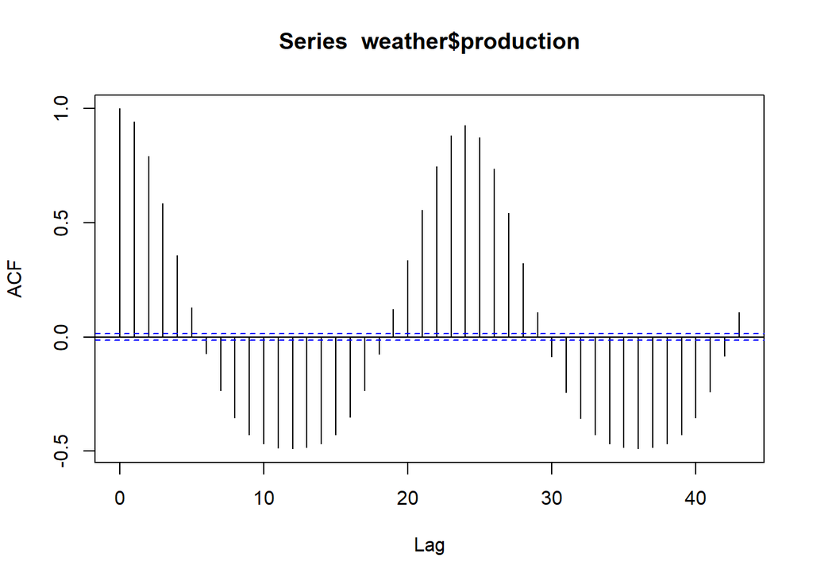

```r
acf(weather$production)
```